# Bike Sharing System Data Characteristics Study

## by Iman Ragab

## Investigation Overview

In this investigation, I wanted to look at the characteristics of Bike Sharing System that could affect other features of the data. The main focus was on trip duration, hour of day, day of week and customer type.

## Dataset Overview

The data set includes information about individual rides made in a bike-sharing system covering the greater San Francisco Bay area. The data consisted of 16 attributes of approximately 183,412 trips. The attributes included data about customers, locations and dates of the trips.

## When are most trips taken in terms of Hours and Days?

As we can see the bimodal distribution for time of the day shows that the most popular hours of the day for rides are 8 AM and 5 PM. These time of the day correspnods to when people go to or coming from work.

While the bivariate distribution of time of the day & day of week show that on weekends, the number of rides starts gradually increasing around 8-9 AM and gradually decreasing around 5-6 PM .

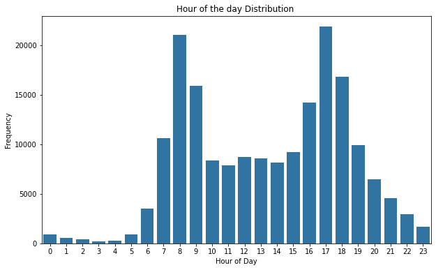

## Relation between Hours of Day and Days of Week.

The bivariate distribution of time of the day & day of week show that on weekends, the number of rides starts gradually increasing around 8-9 AM and gradually decreasing around 5-6 PM .

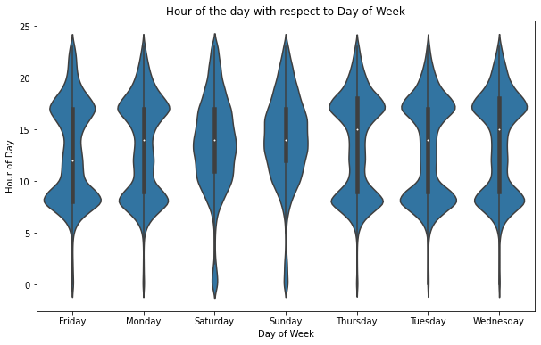

## Trip duration, day of the week & gender

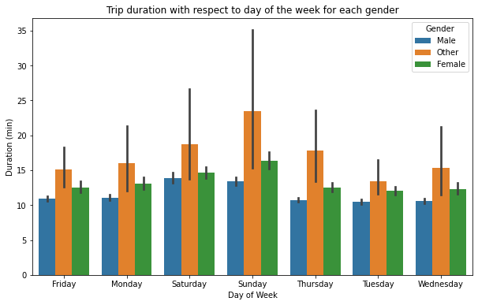